# Multivariate Models Homework

Ian Rolfe

2/16/2023

## Loading in the data and packages

```r
library(vegan)
  # Dataframe/Matrix containing # of observations of different species at 20 unique sites
data(dune)
  # Dataframe/Matrix containing environmental data for the 20 unique sites
data(dune.env)
?dune
```

## Question 1: Indirect Ordination using NMDS

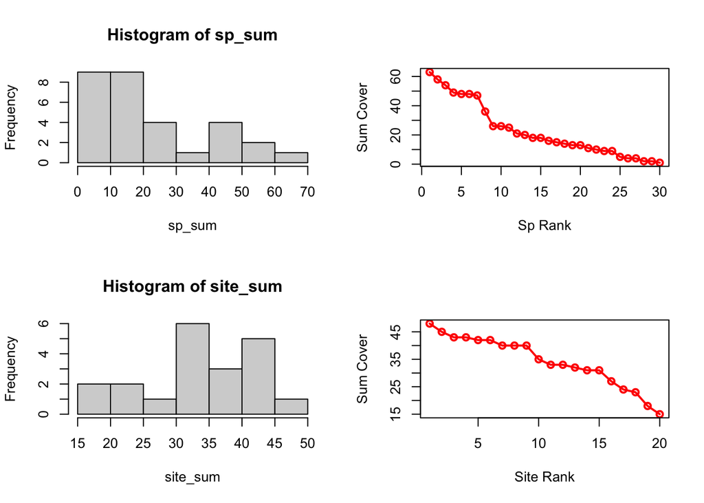

```r
# Making sure everything looks good -- We can see
sp_sum <- apply(dune, 2, sum)
site_sum <- apply(dune, 1, sum)
par(mfrow=c(2,2))
hist(sp_sum)
col <- colorRamp(c('red', 'orange', 'blue'))
plot(sp_sum[order(sp_sum, decreasing=T)], type='o', col='red', lwd=2,
     xlab='Sp Rank', ylab='Sum Cover')
hist(site_sum)
plot(site_sum[order(site_sum, decreasing=T)], type='o', col='red', lwd=2,
     xlab='Site Rank', ylab='Sum Cover')
```

```r
# Steps: Run NMDS, add environmental data (in figure)
dune_mds = metaMDS(dune)
```

```
## *** Best solution repeated 8 times
```

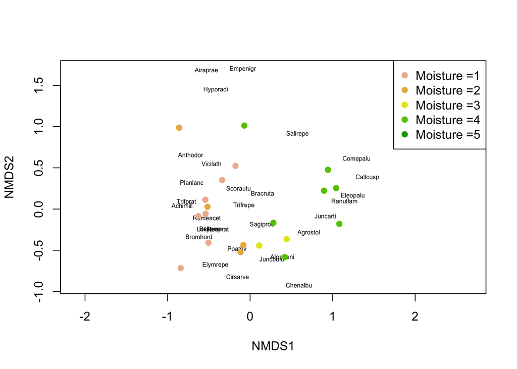

```r
par(mfrow=c(1,1))
plot(dune_mds, type='n')
text(dune_mds, 'sp', cex=.5)
# generate vector of colors
color_vect = rev(terrain.colors(6))[-1]
points(dune_mds, 'sites', pch=19,
       col=color_vect[dune.env$Moisture])
legend('topright', paste("Moisture =", 1:5, sep=''),
       col=color_vect, pch=19)
```

The way to interpret this graph is to look at the spatial orientation of the different species. It is important to remember that you should focus on the orientations as they pertain to the X and Y axes, as the X axis is explaining the most variation and the Y is explaining the second most.

The goal of creating these plots is to find groupings between extensive datasets, and to minimize the number of variables which explain variation between those groupings.

From this figure, you can see that certain species (e.g., Comapalu, Eoleopalu, Juncarti) are grouped closer to the sites with the highest moisture. You can also see that some species (e.g., Anthodor, Vicilath, Planlanc) are grouped closest to sites with low moisture. This analysis shows that some dune species require (or rather exist near) sites which have higher or lower moisture contents.

## Question 2

#### Testing all constrained axes of the model (entire model)

```r
dune_cca <- cca(dune ~ ., data=dune.env)
RsquareAdj(dune_cca, 100)
```

```
## $r.squared
## [1] 0.7106267
##
## $adj.r.squared
## [1] 0.2155614
```

```r
anova(dune_cca, permutations=999)
```

```
## Permutation test for cca under reduced model
## Permutation: free
## Number of permutations: 999
##
## Model: cca(formula = dune ~ A1 + Moisture + Management + Use + Manure, data = dune.env)
##          Df ChiSquare      F Pr(>F)
## Model    12    1.5032 1.4325  0.034 *
## Residual  7    0.6121
## ---
## Signif. codes:  0 '***' 0.001 '**' 0.01 '*' 0.05 '.' 0.1 ' ' 1
```

```r
anova(dune_cca, by="margin", permutations=999)
```

```
## Permutation test for cca under reduced model
## Marginal effects of terms
## Permutation: free
## Number of permutations: 999
##
## Model: cca(formula = dune ~ A1 + Moisture + Management + Use + Manure, data = dune.env)
##            Df ChiSquare      F Pr(>F)
## A1          1   0.11070 1.2660  0.235
## Moisture    3   0.31587 1.2041  0.242
## Management  2   0.15882 0.9081  0.585
## Use         2   0.13010 0.7439  0.802
## Manure      3   0.25490 0.9717  0.511
## Residual    7   0.61210
```

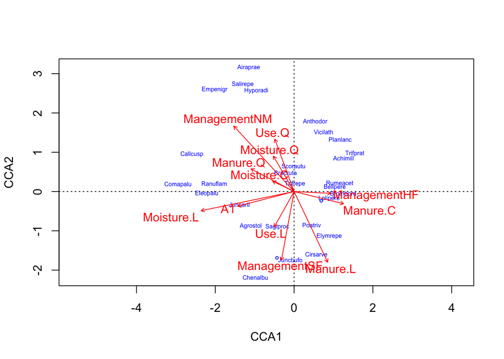

```r
plot(dune_cca, type='n', scaling=1)
orditorp(dune_cca, display='sp', cex=0.5, scaling=1, col='blue')
text(dune_cca, display='bp', col='red')
```

I wanted to test these variables because they look to be important in reference to the X axis in the above graph

```r
dune_cca_moist <- cca(dune ~ Moisture+Manure, data=dune.env)
RsquareAdj(dune_cca_moist, 100)
```

```
## $r.squared
## [1] 0.5111809
##
## $adj.r.squared
## [1] 0.2285259
```

```r
anova(dune_cca_moist, permutations=999)
```

```
## Permutation test for cca under reduced model
## Permutation: free
## Number of permutations: 999
##
## Model: cca(formula = dune ~ Moisture + Manure, data = dune.env)
##          Df ChiSquare      F Pr(>F)
## Model     7    1.0813 1.7927  0.002 **
## Residual 12    1.0340
## ---
## Signif. codes:  0 '***' 0.001 '**' 0.01 '*' 0.05 '.' 0.1 ' ' 1
```

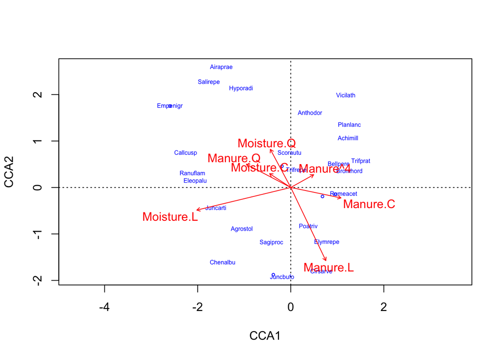

```r
plot(dune_cca_moist, type='n', scaling=1)
orditorp(dune_cca_moist, display='sp', cex=0.5, scaling=1, col='blue')
text(dune_cca_moist, display='bp', col='red')
```

## Question 3

I personally find both to be useful, but I think it is important to refine your analysis after viewing the entire model.

When I was doing the initial exploratory analysis, I found that moisture played a role in determining presence or absence of certain species (this makes ecological sense). By plotting the entire model, I was able to learn more about the impacts of certain explanatory factors, and then the final model was the most refined, with Manure and Moisture being the variables included.

It is important to use models which explain variation while still being simple, so refining to the last model I tested was an important step, and helped raise the Adjusted R-squared value.